# Bayesian Networks in Formula One Race Strategy

Round 1: Bahrain GP 2023

Natalia Kortals

2024-10-23

## EDA

Firstly, we load the data saved into .csv file, acquired using f1dataR package. https://CRAN.R-project.org/package=f1dataR

```r
BAH = data.frame(read.csv("data/bahrain2023.csv", header =TRUE))
head(BAH)
```

```
##   X driver lap_number driver_number lap_time tyre     team position rainfall
## 1 1    ALB          1            23  106.453 SOFT Williams       12      Dry
## 2 2    ALB          2            23  100.430 SOFT Williams       12      Dry
## 3 3    ALB          3            23  100.143 SOFT Williams       12      Dry
## 4 4    ALB          4            23   99.761 SOFT Williams       11      Dry
## 5 5    ALB          5            23  100.606 SOFT Williams       11      Dry
## 6 6    ALB          6            23  100.744 SOFT Williams       11      Dry
##   pitstop_duration start_position traction asphalt_grip asphalt_abrasion
## 1               NA             15        4            3                5
## 2               NA             15        4            3                5
## 3               NA             15        4            3                5
## 4               NA             15        4            3                5
## 5               NA             15        4            3                5
## 6               NA             15        4            3                5
##   track_evol tyre_stress braking lateral downforce
## 1          4           3       4       3         3
## 2          4           3       4       3         3
## 3          4           3       4       3         3
## 4          4           3       4       3         3
## 5          4           3       4       3         3
## 6          4           3       4       3         3
```

```r
summary(BAH)
```

```
##        X             driver            lap_number    driver_number
##  Min.   :   1.0   Length:1056        Min.   : 1.00   Min.   : 1.00
##  1st Qu.: 264.8   Class :character   1st Qu.:14.00   1st Qu.:11.00
##  Median : 528.5   Mode  :character   Median :28.00   Median :21.00
##  Mean   : 528.5                      Mean   :27.91   Mean   :26.24
##  3rd Qu.: 792.2                      3rd Qu.:42.00   3rd Qu.:31.00
##  Max.   :1056.0                      Max.   :57.00   Max.   :81.00
##
##     lap_time          tyre               team              position
##  Min.   : 94.00   Length:1056        Length:1056        Min.   : 1.000
##  1st Qu.: 97.75   Class :character   Class :character   1st Qu.: 5.000
##  Median : 98.61   Mode  :character   Mode  :character   Median :10.000
##  Mean   :100.45                                         Mean   : 9.816
##  3rd Qu.:100.24                                         3rd Qu.:14.000
##  Max.   :138.69                                         Max.   :20.000
##  NA's   :1                                              NA's   :1
##    rainfall         pitstop_duration start_position     traction  asphalt_grip
##  Length:1056        Min.   :24.23    Min.   : 1.00   Min.   :4   Min.   :3
##  Class :character   1st Qu.:24.77    1st Qu.: 5.00   1st Qu.:4   1st Qu.:3
##  Mode  :character   Median :25.27    Median :10.00   Median :4   Median :3
##                     Mean   :27.10    Mean   :10.31   Mean   :4   Mean   :3
##                     3rd Qu.:26.03    3rd Qu.:15.00   3rd Qu.:4   3rd Qu.:3
##                     Max.   :44.52    Max.   :20.00   Max.   :4   Max.   :3
##                     NA's   :1006
##  asphalt_abrasion   track_evol  tyre_stress    braking     lateral    downforce
##  Min.   :5        Min.   :4    Min.   :3    Min.   :4   Min.   :3   Min.   :3
##  1st Qu.:5        1st Qu.:4    1st Qu.:3    1st Qu.:4   1st Qu.:3   1st Qu.:3
##  Median :5        Median :4    Median :3    Median :4   Median :3   Median :3
##  Mean   :5        Mean   :4    Mean   :3    Mean   :4   Mean   :3   Mean   :3
##  3rd Qu.:5        3rd Qu.:4    3rd Qu.:3    3rd Qu.:4   3rd Qu.:3   3rd Qu.:3
##  Max.   :5        Max.   :4    Max.   :3    Max.   :4   Max.   :3   Max.   :3
##
```

Next, we plot the variables to understand the dataset:

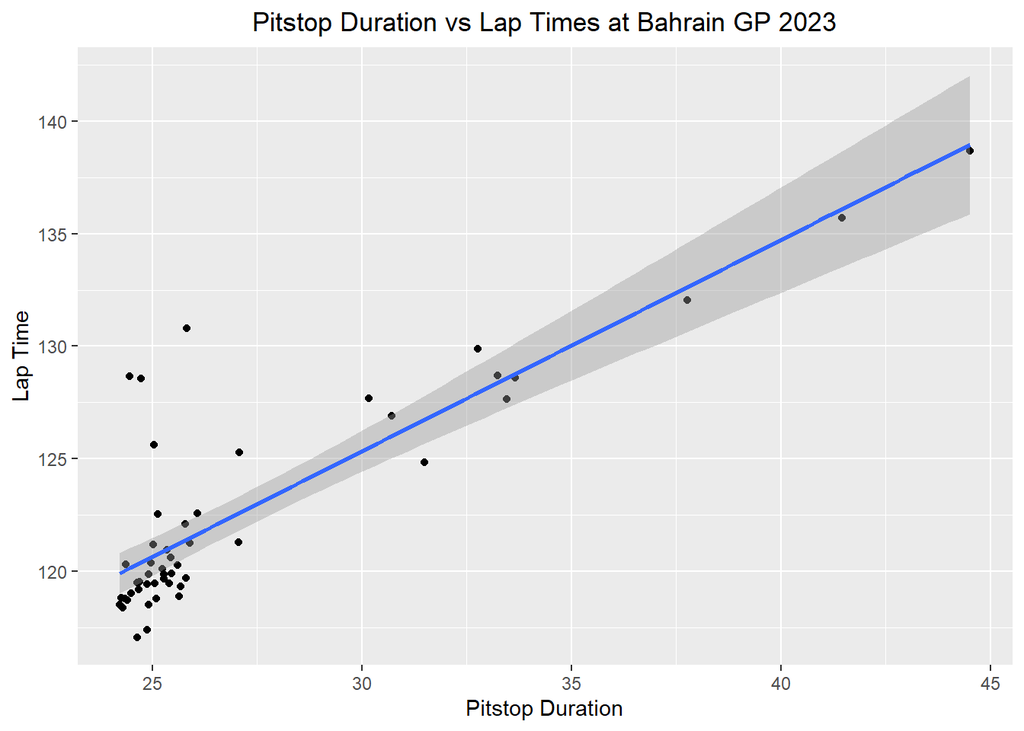

```r
ggplot(data=subset(BAH, !is.na(pitstop_duration)), aes(x=pitstop_duration, y = lap_time)) +
  geom_point()  + geom_smooth(method=lm) +
  labs(x = "Pitstop Duration", y = "Lap Time", title = "Pitstop Duration vs Lap Times at Bahrain GP 2023") +
  theme(plot.title = element_text(hjust=0.5))
```

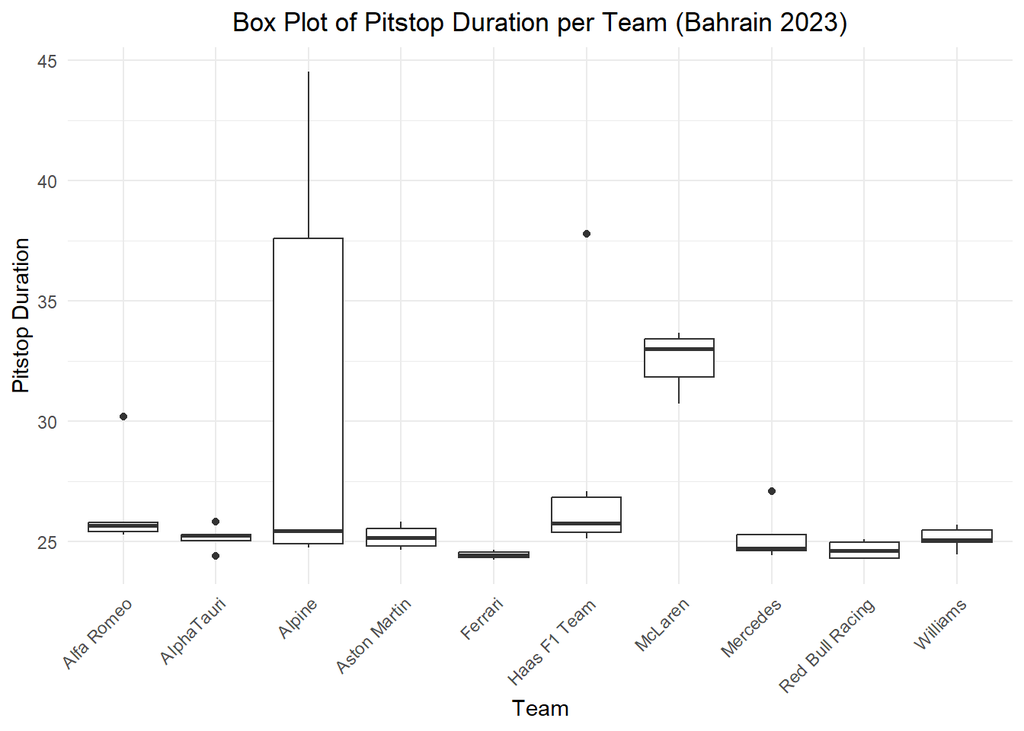

```r
# ggplot() + geom_boxplot(aes(x = BAH$team, y = BAH$pitstop_duration))

ggplot() + geom_boxplot(aes(x = BAH$team, y = BAH$pitstop_duration))+
  labs(x = "Team", y = "Pitstop Duration", title = "Box Plot of Pitstop Duration per Team (Bahrain 2023)") +
  theme_minimal() + theme(axis.text.x = element_text(angle = 45, hjust=1)) +
  theme(plot.title = element_text(hjust = 0.5))
```

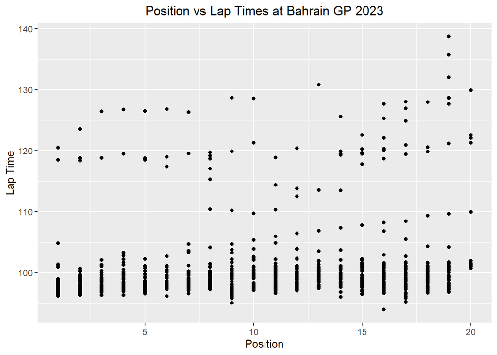

```r
ggplot(data=BAH, aes(x=position, y = lap_time)) +
  geom_point()  + #geom_smooth(method=lm) +
  labs(x = "Position", y = "Lap Time", title = "Position vs Lap Times at Bahrain GP 2023") +
  theme(plot.title = element_text(hjust=0.5))
```

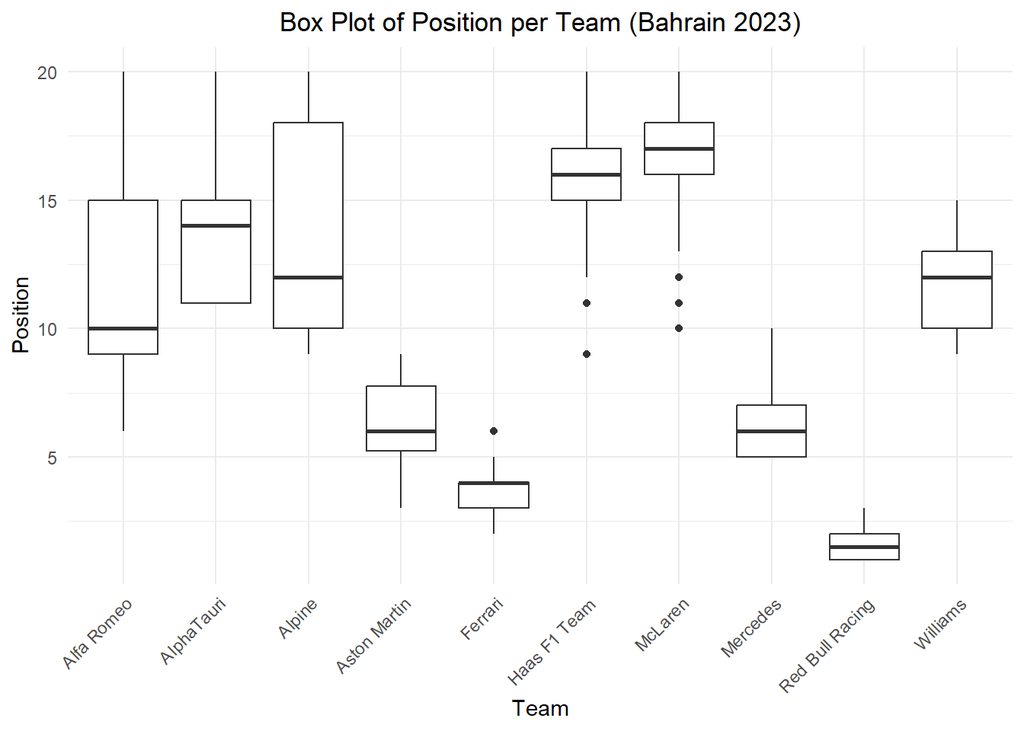

```r
ggplot() + geom_boxplot(aes(x = BAH$team, y = BAH$position))+
  labs(x = "Team", y = "Position", title = "Box Plot of Position per Team (Bahrain 2023)") +
  theme_minimal() + theme(axis.text.x = element_text(angle = 45, hjust=1)) +
  theme(plot.title = element_text(hjust = 0.5))
```

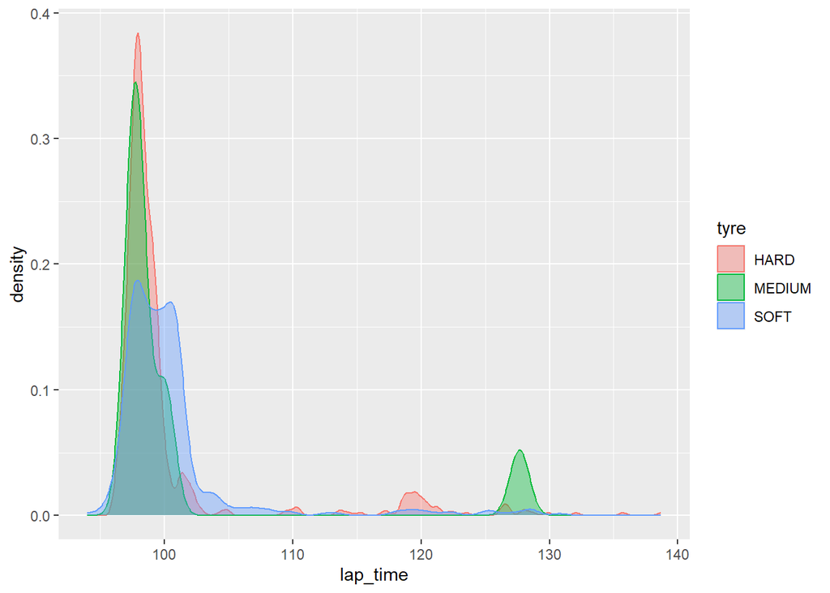

```r
BAH %>%
  ggplot( aes(x=lap_time, colour = tyre, fill = tyre)) +
    geom_density(alpha = 0.4)
```

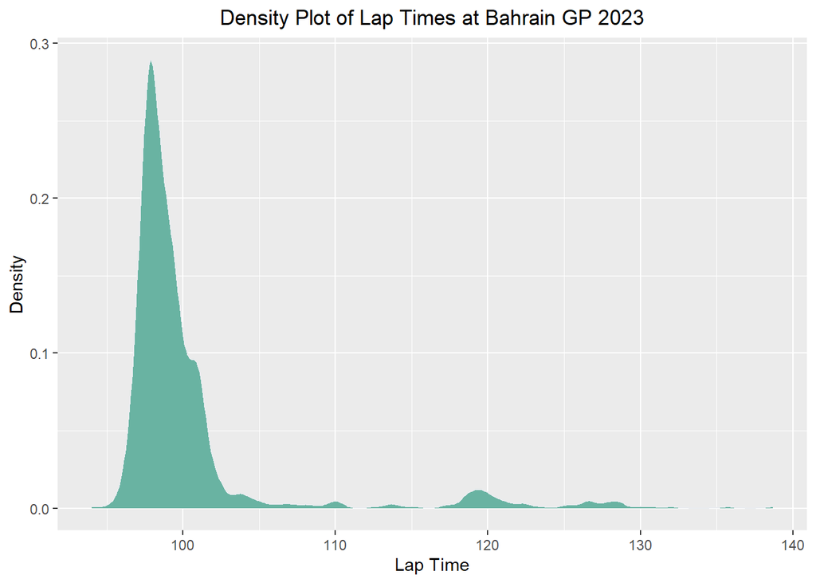

```r
ggplot() +
  geom_density(aes(x = BAH$lap_time), fill="#69b3a2", color="#e9ecef") +
  labs(x = "Lap Time", y = "Density", title = "Density Plot of Lap Times at Bahrain GP 2023") +
  theme(plot.title = element_text(hjust=0.5))
```

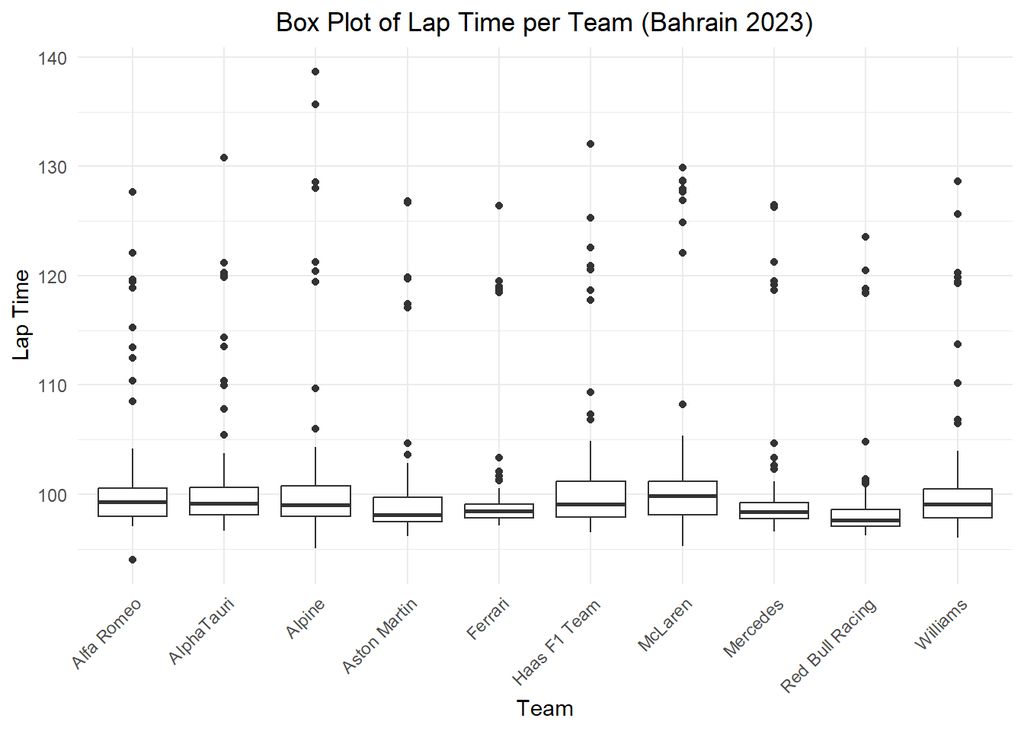

```r
ggplot() + geom_boxplot(aes(x = BAH$team, y = BAH$lap_time))+
  labs(x = "Team", y = "Lap Time", title = "Box Plot of Lap Time per Team (Bahrain 2023)") +
  theme_minimal() + theme(axis.text.x = element_text(angle = 45, hjust=1)) +
  theme(plot.title = element_text(hjust = 0.5))
```

Before pairplot we need to set the categorical variables as factors

```r
BAH$driver <- factor(BAH$driver)
BAH$team <- factor(BAH$team)
BAH$tyre <- factor(BAH$tyre)

# Circuit characteristics
BAH$traction <- factor(BAH$traction, ordered = TRUE)
BAH$asphalt_grip <- factor(BAH$asphalt_grip, ordered = TRUE)
BAH$asphalt_abrasion <- factor(BAH$asphalt_abrasion, ordered = TRUE)
BAH$track_evol <- factor(BAH$track_evol, ordered = TRUE)
BAH$tyre_stress <- factor(BAH$tyre_stress, ordered = TRUE)
BAH$braking <- factor(BAH$braking, ordered = TRUE)
BAH$lateral <- factor(BAH$lateral, ordered = TRUE)
BAH$downforce <- factor(BAH$downforce, ordered = TRUE)
```

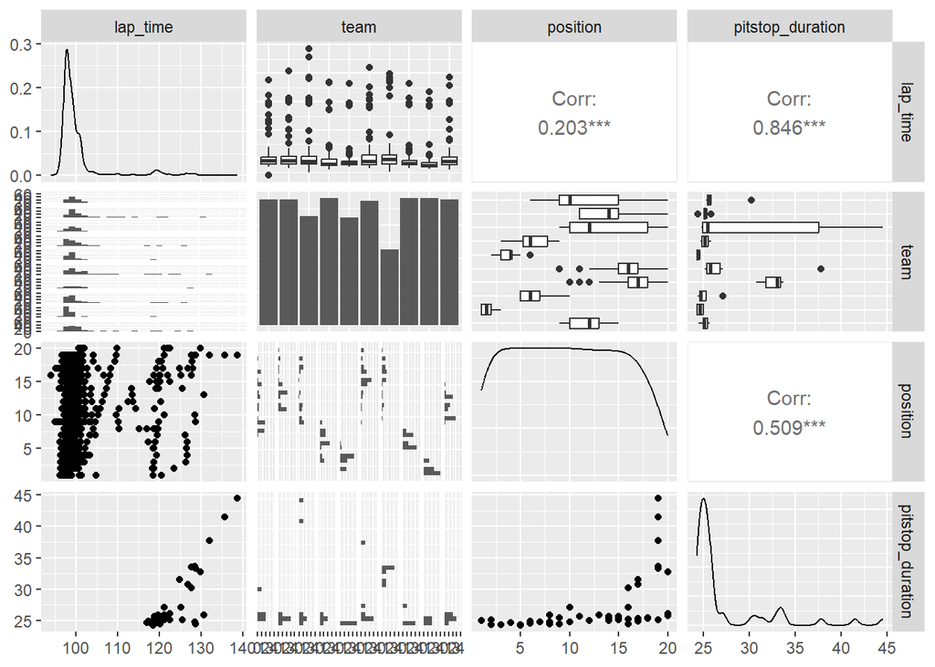

```r
ggpairs(BAH, columns = c("lap_time", "team", "position", "pitstop_duration"))
```

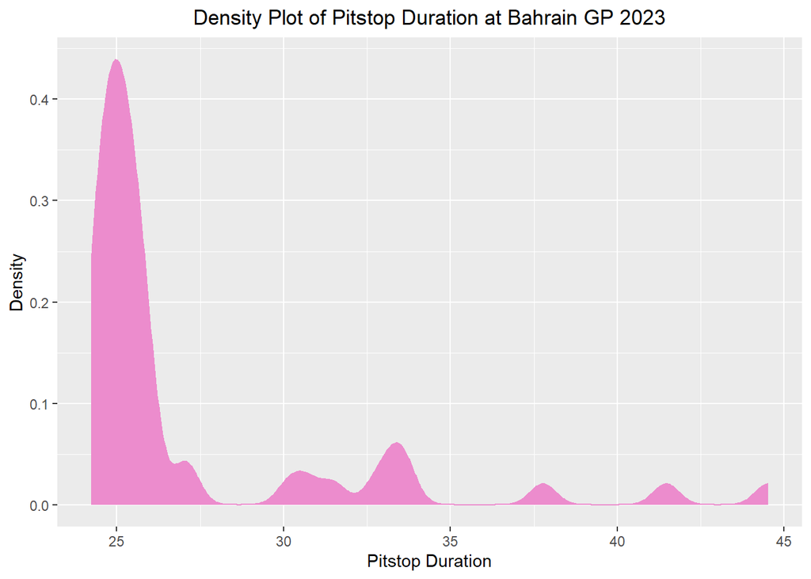

```r
ggplot() +
  geom_density(aes(x = BAH$pitstop_duration), fill="#ec8ccd", color="#ec8ccd") +
  labs(x = "Pitstop Duration", y = "Density", title = "Density Plot of Pitstop Duration at Bahrain GP 2023") +
  theme(plot.title = element_text(hjust=0.5))
```

```r
BAH$pitstop_duration <- as.numeric(BAH$pitstop_duration)

BAH$pitstop_duration <- cut(BAH$pitstop_duration, breaks = c(min(BAH$pitstop_duration, na.rm = TRUE), quantile(BAH$pitstop_duration, probs = c(.2, .4,  .6, .8),na.rm=TRUE),max(BAH$pitstop_duration, na.rm = TRUE)), ordered_result = TRUE, include.lowest = TRUE)
```

```r
BAH$driver <- factor(BAH$driver)
BAH$team <- factor(BAH$team)

# Circuit characteristics
BAH$traction <- factor(BAH$traction, ordered = TRUE)
BAH$asphalt_grip <- factor(BAH$asphalt_grip, ordered = TRUE)
BAH$asphalt_abrasion <- factor(BAH$asphalt_abrasion, ordered = TRUE)
BAH$track_evol <- factor(BAH$track_evol, ordered = TRUE)
BAH$tyre_stress <- factor(BAH$tyre_stress, ordered = TRUE)
BAH$braking <- factor(BAH$braking, ordered = TRUE)
BAH$lateral <- factor(BAH$lateral, ordered = TRUE)
BAH$downforce <- factor(BAH$downforce, ordered = TRUE)

# Lap time - ordered: the shorter the better
# the fastest lap is included thanks to argument include.lowest = TRUE
BAH$lap_time <- cut(BAH$lap_time, breaks = c(min(BAH$lap_time, na.rm = TRUE), quantile(BAH$lap_time,probs = c(.02, .05, .1, .15, .2, .3,.4,.5,.6, .7,.8, .85, .9, .95, .98),na.rm=TRUE),max(BAH$lap_time, na.rm = TRUE)), include.lowest = TRUE, ordered_result = TRUE)

# Add "no_pitstop" to the factor levels for pitstop_duration
BAH$pitstop_duration <- factor(BAH$pitstop_duration,
                                levels = c("no_pitstop", levels(BAH$pitstop_duration)))
# Replace all NA values with "no_pitstop"
BAH <- BAH %>% replace_na(list(pitstop_duration = "no_pitstop"))


BAH$tyre <- factor(BAH$tyre)
BAH$rainfall <- factor(BAH$rainfall, ordered = TRUE)

# Make a variable for position on previous lap
BAH <- BAH %>%
  mutate(previous_position = ifelse(lap_number == 1, start_position, shift(BAH$position, n=1, type="lag")))

# Positions are ordered
BAH$previous_position <- factor(BAH$previous_position, ordered = TRUE)
BAH$position <- factor(BAH$position, ordered = TRUE)
```

```r
levels(BAH$lap_time)
```

```
##  [1] "[94,96.43]"    "(96.43,96.89]" "(96.89,97.22]" "(97.22,97.43]"
##  [5] "(97.43,97.6]"  "(97.6,97.87]"  "(97.87,98.18]" "(98.18,98.61]"
##  [9] "(98.61,99.12]" "(99.12,99.73]" "(99.73,100.8]" "(100.8,101.2]"
## [13] "(101.2,102.6]" "(102.6,118.8]" "(118.8,124.7]" "(124.7,138.7]"
```

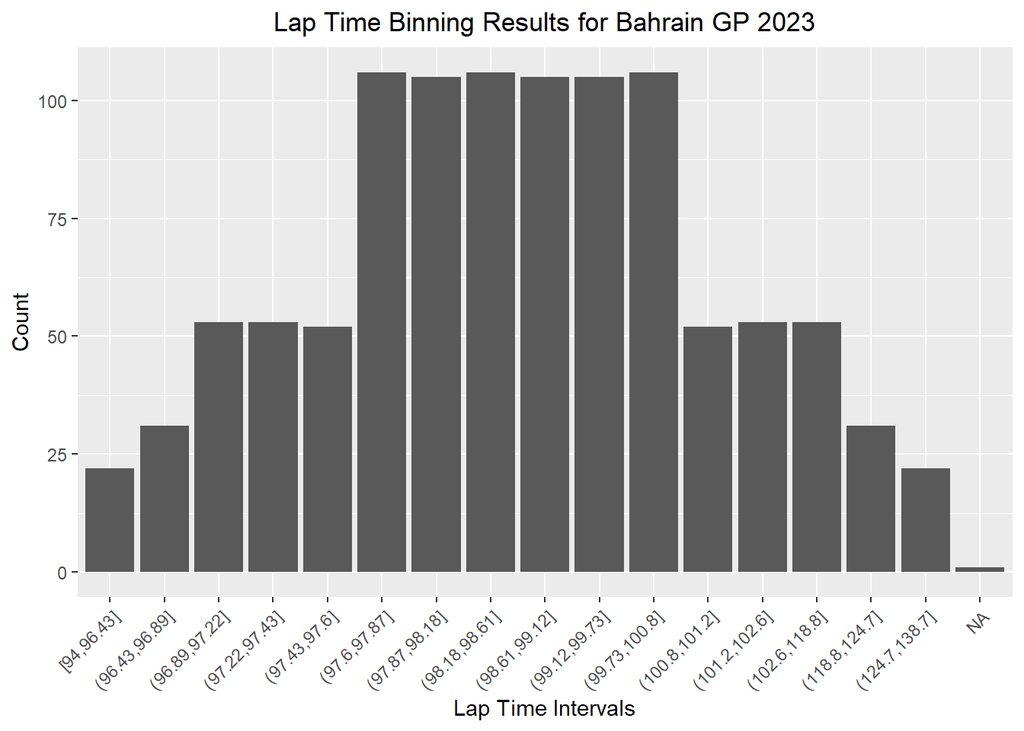

```r
ggplot() + geom_bar(aes(x = BAH$lap_time))+
  labs(x = "Lap Time Intervals", y = "Count", title="Lap Time Binning Results for Bahrain GP 2023")+
theme(axis.text.x = element_text(angle = 45, hjust=1), plot.title = element_text(hjust=0.5))
```

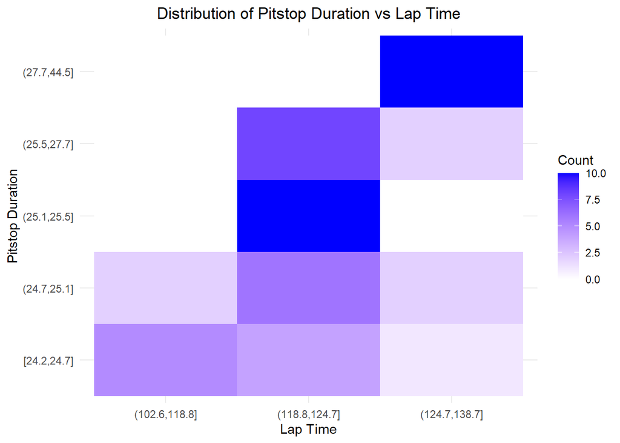

```r
count_LTPT <- BAH %>%
  filter(pitstop_duration != "no_pitstop") %>%
  count(pitstop_duration, lap_time) %>%
  spread(lap_time, n, fill = 0)

heatmap_data <- gather(count_LTPT, key = "lap_time", value = "count", -pitstop_duration)

ggplot(heatmap_data, aes(x = lap_time, y = pitstop_duration, fill = count)) +
  geom_tile() +
  scale_fill_gradient(low = "white", high = "blue") +
  labs(title = "Distribution of Pitstop Duration vs Lap Time",
       x = "Lap Time",
       y = "Pitstop Duration",
       fill = "Count") +
  theme_minimal() +
  theme(plot.title = element_text(hjust=0.5))
```

```r
# check which rows have NAs and investigate why
which(is.na(BAH))
```

```
## [1] 4661 7829
```

```r
# dropping  nas
BAH <- drop_na(BAH)
```

```r
# if starting position is 0, raise a Warning to check if that was a pitlane start
BAH %>%
  group_by(team) %>%
  summarize(has_zero = any(previous_position == 0), .groups = "drop") %>%
  filter(has_zero) %>%
  pull(team) -> drivers_with_zero

# Raise warning if any drivers seem to be starting from pitlane - check with reports on F1 website
if (length(drivers_with_zero) > 0) {
  warning(paste("The following drivers have starting position = 0:", paste(drivers_with_zero, collapse = ", ")))
}
```

# Simple DAG

## Known DAG.

Suppose we want to model the Bahrain GP with 5 variables: lap time, tyre compound, team, position, pitstop duration.

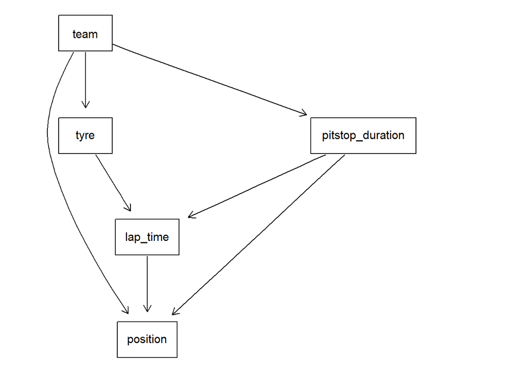

```r
library(bnlearn)
library(Rgraphviz)
# Choosing relevant variables
BAH1 <- BAH %>%  dplyr::select(c(lap_time,
                                  tyre, team, position,
                                pitstop_duration))

dag = empty.graph(nodes = c("lap_time", "tyre", "team", "position", "pitstop_duration"))
# Known relationships
arc.set = matrix(c("team", "position",
                   "team", "tyre",
                   "lap_time", "position",
                   "tyre", "lap_time",
                  "pitstop_duration", "lap_time",
                   "pitstop_duration", "position",
                  "team", "pitstop_duration"),
                 byrow = TRUE, ncol=2, dimnames =list(NULL,c("from","to")))
arcs(dag) = arc.set
graphviz.plot(dag)
```

```r
arc.strength(dag, data = BAH1, criterion = "x2")
```

```
##               from               to      strength
## 1             team         position  1.000000e+00
## 2             team             tyre  1.143651e-50
## 3         lap_time         position  1.000000e+00
## 4             tyre         lap_time  3.734665e-01
## 5 pitstop_duration         lap_time 1.770481e-183
## 6 pitstop_duration         position  1.000000e+00
## 7             team pitstop_duration  5.963552e-05
```

```r
bn.bayes = bn.fit(dag,data=BAH1, method = "bayes", iss = 10)

bn.bayes$pitstop_duration
```

```
##
##   Parameters of node pitstop_duration (ordinal distribution)
##
## Conditional probability table:
##
##                 team
## pitstop_duration  Alfa Romeo  AlphaTauri      Alpine Aston Martin     Ferrari
##      no_pitstop  0.948830409 0.948830409 0.930976431  0.957971014 0.950171821
##      [24.2,24.7] 0.001461988 0.010233918 0.001683502  0.010144928 0.042955326
##      (24.7,25.1] 0.001461988 0.010233918 0.031986532  0.010144928 0.001718213
##      (25.1,25.5] 0.019005848 0.019005848 0.001683502  0.010144928 0.001718213
##      (25.5,27.7] 0.019005848 0.010233918 0.011784512  0.010144928 0.001718213
##      (27.7,44.5] 0.010233918 0.001461988 0.021885522  0.001449275 0.001718213
##                 team
## pitstop_duration Haas F1 Team     McLaren    Mercedes Red Bull Racing
##      no_pitstop   0.939528024 0.900966184 0.957971014     0.957971014
##      [24.2,24.7]  0.001474926 0.002415459 0.010144928     0.018840580
##      (24.7,25.1]  0.001474926 0.002415459 0.018840580     0.010144928
##      (25.1,25.5]  0.028023599 0.002415459 0.001449275     0.010144928
##      (25.5,27.7]  0.019174041 0.002415459 0.010144928     0.001449275
##      (27.7,44.5]  0.010324484 0.089371981 0.001449275     0.001449275
##                 team
## pitstop_duration    Williams
##      no_pitstop  0.940058480
##      [24.2,24.7] 0.010233918
##      (24.7,25.1] 0.019005848
##      (25.1,25.5] 0.010233918
##      (25.5,27.7] 0.019005848
##      (27.7,44.5] 0.001461988
```

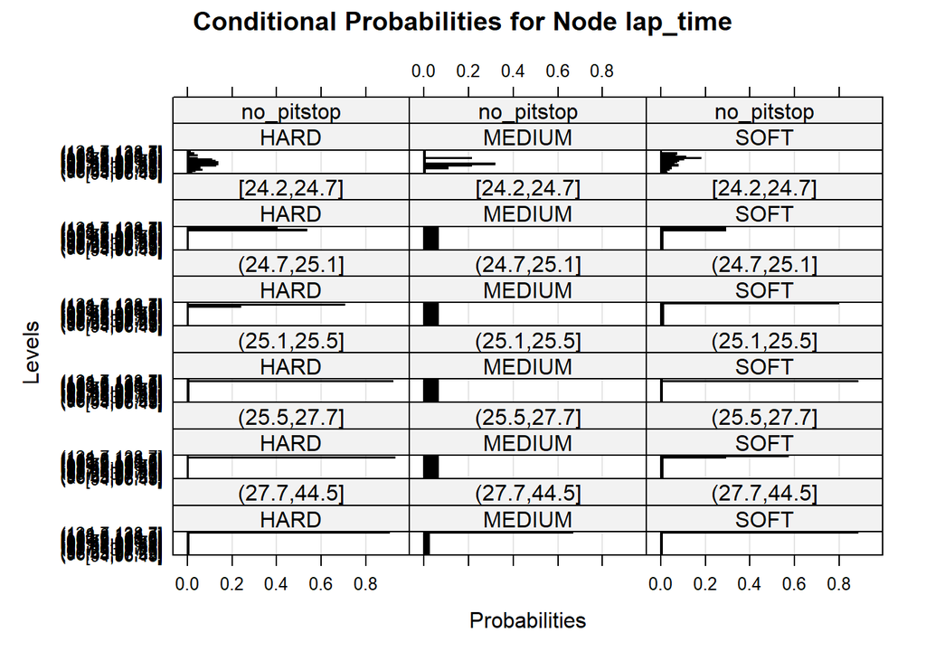

```r
bn.fit.barchart(bn.bayes$lap_time)
```

```r
bn.fit.barchart(bn.bayes$tyre)
```

[output not shown]

```r
bn.fit.barchart(bn.bayes$tyre)
```

[output not shown]

```r
bn.bayes$position$prob[,,5,1]
```

```
##         lap_time
## position   [94,96.43] (96.43,96.89] (96.89,97.22] (97.22,97.43] (97.43,97.6]
##       1  5.000000e-02  5.000000e-02  1.730104e-04  8.665511e-05 8.665511e-05
##       2  5.000000e-02  5.000000e-02  1.730104e-04  8.665511e-05 8.665511e-05
##       3  5.000000e-02  5.000000e-02  6.645329e-01  8.319757e-01 1.664645e-01
##       4  5.000000e-02  5.000000e-02  3.323529e-01  1.664645e-01 4.992201e-01
##       5  5.000000e-02  5.000000e-02  1.730104e-04  8.665511e-05 3.328423e-01
##       6  5.000000e-02  5.000000e-02  1.730104e-04  8.665511e-05 8.665511e-05
##       7  5.000000e-02  5.000000e-02  1.730104e-04  8.665511e-05 8.665511e-05
##       8  5.000000e-02  5.000000e-02  1.730104e-04  8.665511e-05 8.665511e-05
##       9  5.000000e-02  5.000000e-02  1.730104e-04  8.665511e-05 8.665511e-05
##       10 5.000000e-02  5.000000e-02  1.730104e-04  8.665511e-05 8.665511e-05
##       11 5.000000e-02  5.000000e-02  1.730104e-04  8.665511e-05 8.665511e-05
##       12 5.000000e-02  5.000000e-02  1.730104e-04  8.665511e-05 8.665511e-05
##       13 5.000000e-02  5.000000e-02  1.730104e-04  8.665511e-05 8.665511e-05
```

[output cut: 73 more lines]

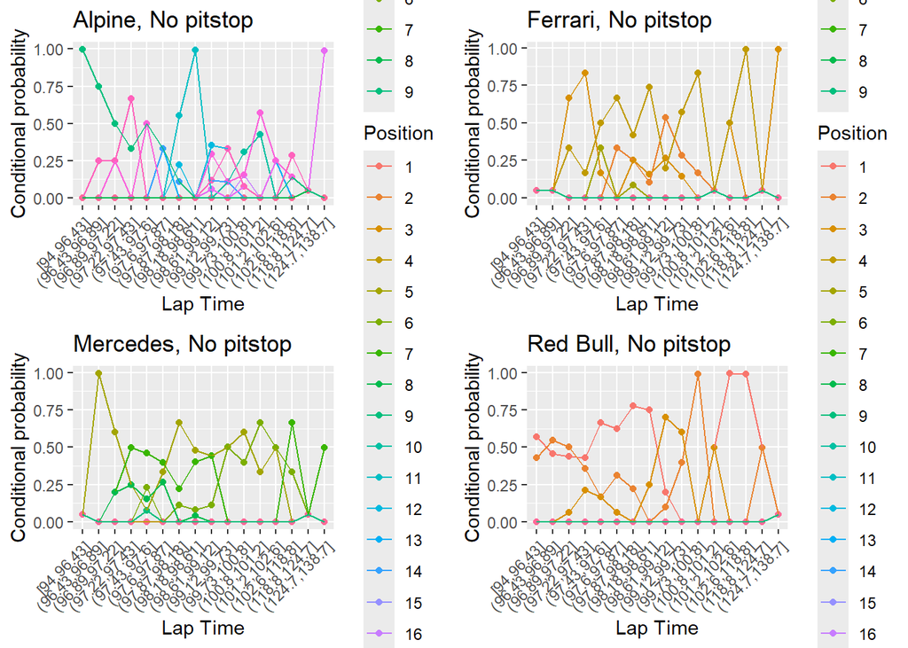

```r
p1 = ggplot(mapping = aes(x = rep(seq(1:length(levels(BAH1$lap_time))),20),
                     y=matrix(t(bn.bayes$position$prob[,,3,1]), ncol =1), color = rep(levels(BAH1$position), each = length(levels(BAH1$lap_time))))) +
  geom_point() +
  geom_line() +
  scale_x_discrete(limits=levels(BAH1$lap_time)) +
  scale_color_discrete(limits = sort(unique(BAH1$position))) +
  labs(x = "Lap Time", y= "Conditional probability", color = "Position", title ="Alpine, No pitstop")+
  theme(axis.text.x = element_text(angle = 45, hjust = 1))
p2 = ggplot(mapping = aes(x = rep(seq(1:length(levels(BAH1$lap_time))),20),
                     y=matrix(t(bn.bayes$position$prob[,,5,1]), ncol =1), color = rep(levels(BAH1$position), each = length(levels(BAH1$lap_time))))) +
  geom_point() +
  geom_line() +
  scale_x_discrete(limits=levels(BAH1$lap_time)) +
  scale_color_discrete(limits = sort(unique(BAH1$position))) +
  labs(x = "Lap Time", y= "Conditional probability", color = "Position", title ="Ferrari, No pitstop")+
  theme(axis.text.x = element_text(angle = 45, hjust = 1))
p3 = ggplot(mapping = aes(x = rep(seq(1:length(levels(BAH1$lap_time))),20),
                     y=matrix(t(bn.bayes$position$prob[,,8,1]), ncol =1), color = rep(levels(BAH1$position), each = length(levels(BAH1$lap_time))))) +
  geom_point() +
  geom_line() +
  scale_x_discrete(limits=levels(BAH1$lap_time)) +
  scale_color_discrete(limits = sort(unique(BAH1$position))) +
  labs(x = "Lap Time", y= "Conditional probability", color = "Position", title ="Mercedes, No pitstop")+
  theme(axis.text.x = element_text(angle = 45, hjust = 1))
p4 = ggplot(mapping = aes(x = rep(seq(1:length(levels(BAH1$lap_time))),20),
                     y=matrix(t(bn.bayes$position$prob[,,9,1]), ncol =1), color = rep(levels(BAH1$position), each = length(levels(BAH1$lap_time))))) +
  geom_point() +
  geom_line() +
  scale_x_discrete(limits=levels(BAH1$lap_time)) +
  scale_color_discrete(limits = sort(unique(BAH1$position))) +
  labs(x = "Lap Time", y= "Conditional probability", color = "Position", title ="Red Bull, No pitstop")+
  theme(axis.text.x = element_text(angle = 45, hjust = 1))
grid.arrange(p1, p2, p3, p4, nrow = 2)
```

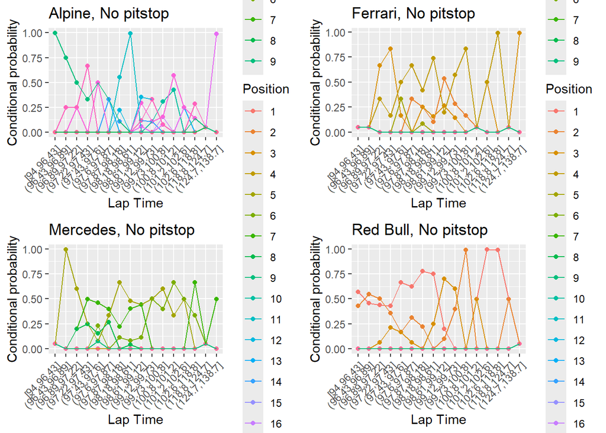

```r
ggsave("cond_lineplots.png",
       grid.arrange(p1, p2, p3, p4, nrow = 2),
       width = 16, height = 12)
```

```r
bn.bayes$lap_time
```

```
##
##   Parameters of node lap_time (ordinal distribution)
##
## Conditional probability table:
##
## , , pitstop_duration = no_pitstop
##
##                tyre
## lap_time                HARD       MEDIUM         SOFT
##   [94,96.43]    1.806250e-02 3.633721e-03 2.725528e-02
##   (96.43,96.89] 3.606250e-02 3.633721e-03 2.499056e-02
##   (96.89,97.22] 6.486250e-02 3.633721e-03 3.857889e-02
##   (97.22,97.43] 5.586250e-02 1.082849e-01 4.763777e-02
##   (97.43,97.6]  5.766250e-02 1.082849e-01 4.310833e-02
##   (97.6,97.87]  1.260625e-01 2.129360e-01 7.707914e-02
##   (97.87,98.18] 1.368625e-01 3.175872e-01 5.896137e-02
##   (98.18,98.61] 1.350625e-01 3.633721e-03 7.028498e-02
##   (98.61,99.12] 1.242625e-01 3.633721e-03 8.160858e-02
##   (99.12,99.73] 1.080625e-01 3.633721e-03 1.019911e-01
##   (99.73,100.8] 4.506250e-02 2.129360e-01 1.789916e-01
##   (100.8,101.2] 5.462500e-03 3.633721e-03 1.110499e-01
##   (101.2,102.6] 4.326250e-02 3.633721e-03 6.575554e-02
##   (102.6,118.8] 2.706250e-02 3.633721e-03 7.028498e-02
##   (118.8,124.7] 3.662500e-03 3.633721e-03 2.343357e-03
##   (124.7,138.7] 1.266250e-02 3.633721e-03 7.863613e-05
##
## , , pitstop_duration = [24.2,24.7]
##
##                tyre
## lap_time                HARD       MEDIUM         SOFT
##   [94,96.43]    4.595588e-03 6.250000e-02 9.765625e-03
##   (96.43,96.89] 4.595588e-03 6.250000e-02 9.765625e-03
##   (96.89,97.22] 4.595588e-03 6.250000e-02 9.765625e-03
##   (97.22,97.43] 4.595588e-03 6.250000e-02 9.765625e-03
##   (97.43,97.6]  4.595588e-03 6.250000e-02 9.765625e-03
##   (97.6,97.87]  4.595588e-03 6.250000e-02 9.765625e-03
##   (97.87,98.18] 4.595588e-03 6.250000e-02 9.765625e-03
##   (98.18,98.61] 4.595588e-03 6.250000e-02 9.765625e-03
##   (98.61,99.12] 4.595588e-03 6.250000e-02 9.765625e-03
##   (99.12,99.73] 4.595588e-03 6.250000e-02 9.765625e-03
```

[output cut: 75 more lines]

```
##   (96.43,96.89] 6.250000e-03 2.232143e-02 7.621951e-03
##   (96.89,97.22] 6.250000e-03 2.232143e-02 7.621951e-03
##   (97.22,97.43] 6.250000e-03 2.232143e-02 7.621951e-03
##   (97.43,97.6]  6.250000e-03 2.232143e-02 7.621951e-03
##   (97.6,97.87]  6.250000e-03 2.232143e-02 7.621951e-03
##   (97.87,98.18] 6.250000e-03 2.232143e-02 7.621951e-03
##   (98.18,98.61] 6.250000e-03 2.232143e-02 7.621951e-03
##   (98.61,99.12] 6.250000e-03 2.232143e-02 7.621951e-03
##   (99.12,99.73] 6.250000e-03 2.232143e-02 7.621951e-03
##   (99.73,100.8] 6.250000e-03 2.232143e-02 7.621951e-03
##   (100.8,101.2] 6.250000e-03 2.232143e-02 7.621951e-03
##   (101.2,102.6] 6.250000e-03 2.232143e-02 7.621951e-03
##   (102.6,118.8] 6.250000e-03 2.232143e-02 7.621951e-03
##   (118.8,124.7] 6.250000e-03 2.232143e-02 7.621951e-03
##   (124.7,138.7] 9.062500e-01 6.651786e-01 8.856707e-01
```

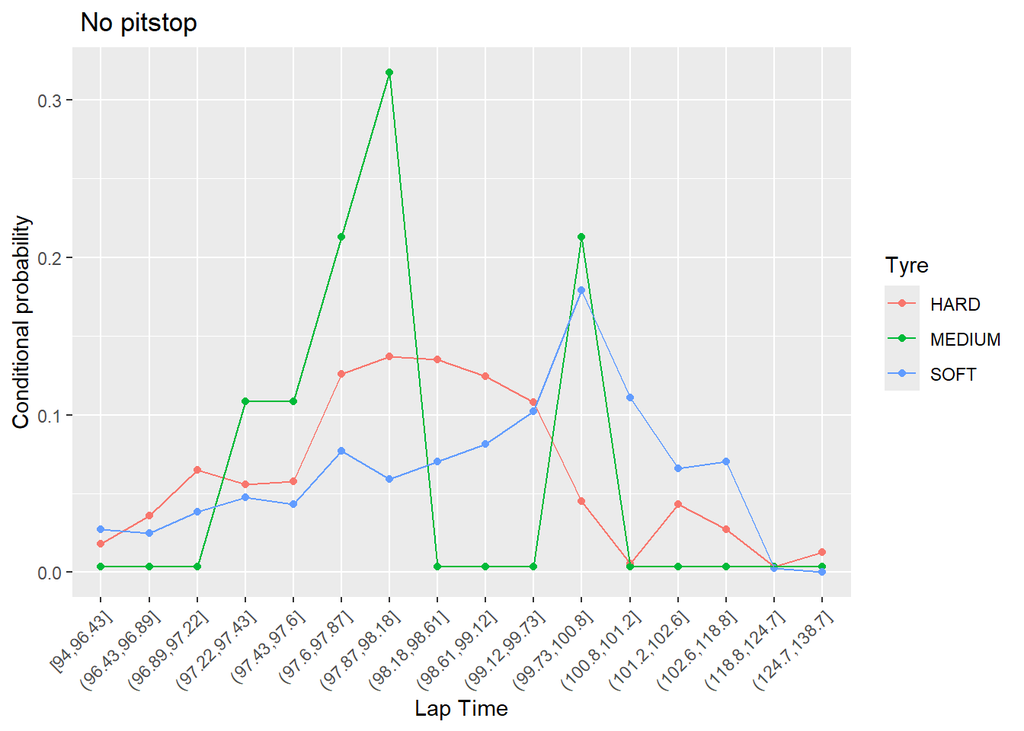

```r
p5 = ggplot(mapping = aes(x = rep(seq(1:length(levels(BAH1$lap_time))),3),
                     y=matrix((bn.bayes$lap_time$prob[,,1]), ncol =1), color = rep(levels(BAH1$tyre), each = length(levels(BAH1$lap_time))))) +
  geom_point() +
  geom_line() +
  scale_x_discrete(limits=levels(BAH1$lap_time)) +
  scale_color_discrete(limits = sort(unique(BAH1$tyre))) +
  labs(x = "Lap Time", y= "Conditional probability", color = "Tyre", title =" No pitstop")+
  theme(axis.text.x = element_text(angle = 45, hjust = 1))
p5
```

## DAG unknown: constraint-based method (incremental association Markov blanket)

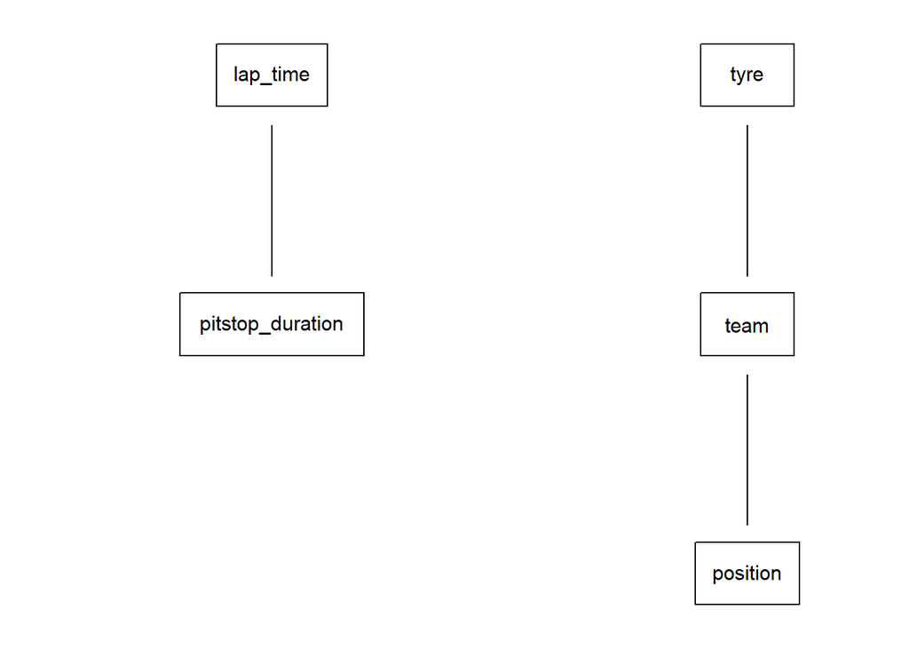

```r
BAH.iamb_naive =iamb(BAH1, test ='mi')
graphviz.plot(BAH.iamb_naive)
```

Make a blacklist representing the natural temporal ordering of variables

```r
# Blacklist variables so that chronological order is kept
bl = matrix(c(
              "lap_time", "pitstop_duration",
              "lap_time", "tyre"
             ),
            ncol = 2, byrow = TRUE)

# Nothing from position
for (name in names(BAH1)){
  bl2 = matrix(c("position", name), ncol=2,
            dimnames =list(NULL,c("from","to")))
  bl = rbind(bl, bl2)
}


# Nothing to team
for (name in names(BAH1)){
  bl3 = matrix(c(name, "team"), ncol=2,
            dimnames =list(NULL,c("from","to")))
  bl = rbind(bl, bl3)
}



bl
```

```
##       from               to
##  [1,] "lap_time"         "pitstop_duration"
##  [2,] "lap_time"         "tyre"
##  [3,] "position"         "lap_time"
##  [4,] "position"         "tyre"
##  [5,] "position"         "team"
##  [6,] "position"         "position"
##  [7,] "position"         "pitstop_duration"
##  [8,] "lap_time"         "team"
##  [9,] "tyre"             "team"
## [10,] "team"             "team"
## [11,] "position"         "team"
## [12,] "pitstop_duration" "team"
```

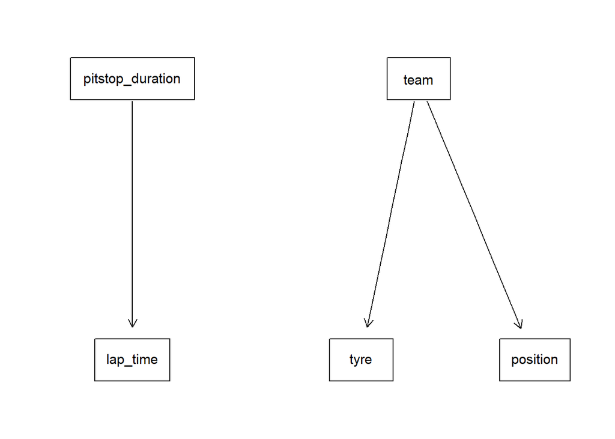

```r
BAH.iamb =iamb(BAH1, blacklist = bl, test ='mi')
graphviz.plot(BAH.iamb)
```

### Perform independence tests

```r
# Does pitstop influence lap time?
ci.test("lap_time","pitstop_duration", test = "mc-jt", data = BAH1)
```

```
##
##  Jonckheere-Terpstra (MC)
##
## data:  lap_time ~ pitstop_duration
## mc-jt = 11.857, Monte Carlo samples = 5000, p-value < 2.2e-16
## alternative hypothesis: true value is not equal to 0
```

```r
# Does team influence position?
ci.test("position", "team", test = "mc-mi", data = BAH1)
```

```
##
##  Mutual Information (disc., MC)
##
## data:  position ~ team
## mc-mi = 2666.5, Monte Carlo samples = 5000, p-value < 2.2e-16
## alternative hypothesis: true value is greater than 0
```

```r
# Does team influence tyre?
ci.test("tyre", "team", test = "mc-mi", data = BAH1)
```

```
##
##  Mutual Information (disc., MC)
##
## data:  tyre ~ team
## mc-mi = 204.29, Monte Carlo samples = 5000, p-value < 2.2e-16
## alternative hypothesis: true value is greater than 0
```

```r
# Does team influence pitstop_duration?
ci.test("pitstop_duration", "team", test = "mc-mi", data = BAH1)
```

```
##
##  Mutual Information (disc., MC)
##
## data:  pitstop_duration ~ team
## mc-mi = 73.072, Monte Carlo samples = 5000, p-value = 0.0088
## alternative hypothesis: true value is greater than 0
```

```r
# Does team influence lap_time?
ci.test("lap_time", "team", "pitstop_duration", test = "mc-mi", data = BAH1)
```

```
##
##  Mutual Information (disc., MC)
##
## data:  lap_time ~ team | pitstop_duration
## mc-mi = 384.91, Monte Carlo samples = 5000, p-value < 2.2e-16
## alternative hypothesis: true value is greater than 0
```

```r
# Does lap_time influence position?
ci.test("position", "lap_time", "team", test = "mc-mi", data = BAH1)
```

```
##
##  Mutual Information (disc., MC)
##
## data:  position ~ lap_time | team
## mc-mi = 1331.1, Monte Carlo samples = 5000, p-value < 2.2e-16
## alternative hypothesis: true value is greater than 0
```

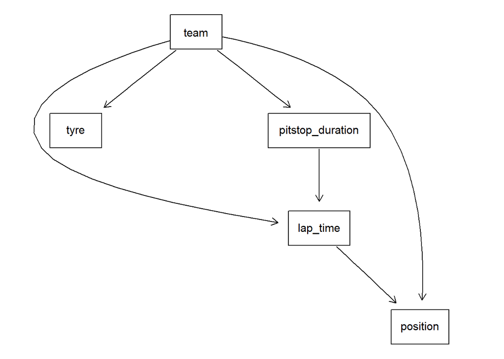

```r
# Add the arcs from conditional independence tests with resulting p-value < 0.05
tested_BAH.iamb = set.arc(BAH.iamb, from = "lap_time", to = "position")
tested_BAH.iamb = set.arc(tested_BAH.iamb, from = "team", to = "lap_time")
tested_BAH.iamb = set.arc(tested_BAH.iamb, from = "team", to = "pitstop_duration")


graphviz.plot(tested_BAH.iamb)
```

```r
# Does pitstop influence position?
ci.test("position", "pitstop_duration", "team", test = "mc-mi", data = BAH1)
```

```
##
##  Mutual Information (disc., MC)
##
## data:  position ~ pitstop_duration | team
## mc-mi = 219.76, Monte Carlo samples = 5000, p-value < 2.2e-16
## alternative hypothesis: true value is greater than 0
```

```r
# Does tyre influence lap time?
ci.test("lap_time","tyre", c("pitstop_duration"), test = "mc-mi", data = BAH1)
```

```
##
##  Mutual Information (disc., MC)
##
## data:  lap_time ~ tyre | pitstop_duration
## mc-mi = 201.64, Monte Carlo samples = 5000, p-value < 2.2e-16
## alternative hypothesis: true value is greater than 0
```

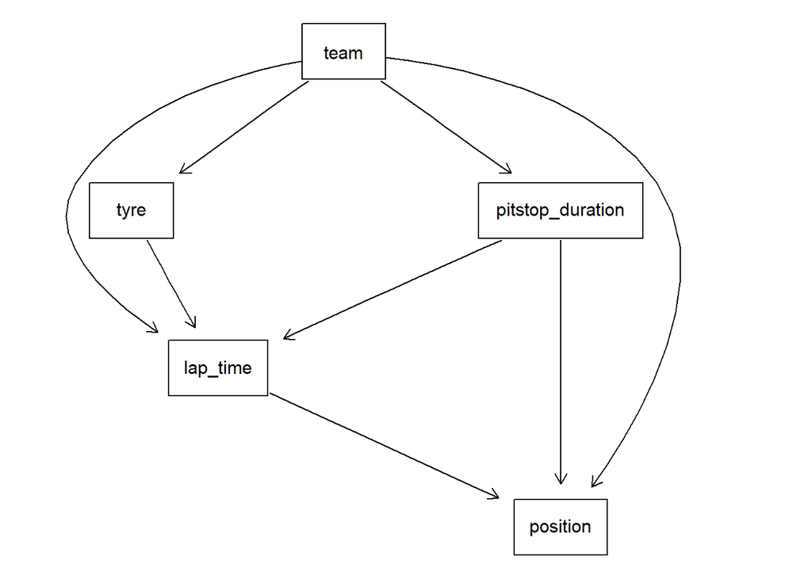

```r
tested_BAH.iamb = set.arc(tested_BAH.iamb, from = "pitstop_duration", to = "position")
tested_BAH.iamb = set.arc(tested_BAH.iamb, from = "tyre", to = "lap_time")
graphviz.plot(tested_BAH.iamb)
```

## DAG uknown: score-based method (hill-climbing)

```r
# Use hill-climbing to determine the DAG
BAH.hc1 =hc(BAH1)
```

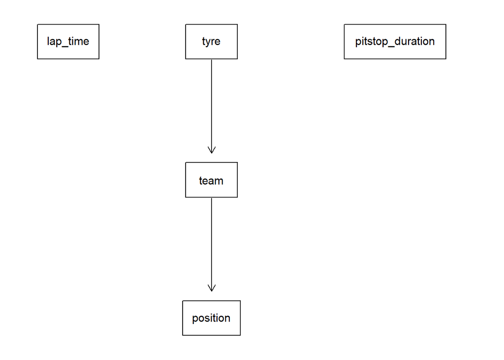

```r
graphviz.plot(BAH.hc1)
```

Learning DAG using hill climbing and whitelists, blacklists

```r
# Use hill-climbing to determine the DAG with blacklisting
BAH.hc_bl =hc(BAH1, blacklist = bl)
```

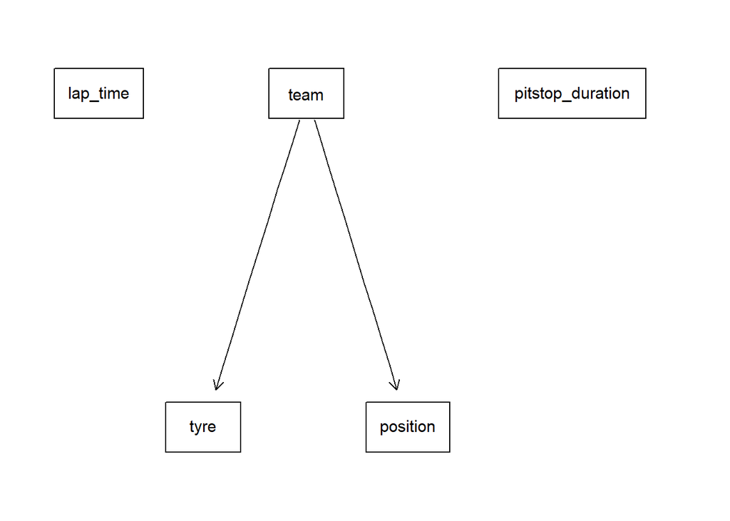

```r
graphviz.plot(BAH.hc_bl)
```

```r
arc.strength(BAH.hc_bl, data = BAH1, criterion = "x2")
```

```
##   from       to     strength
## 1 team position 0.000000e+00
## 2 team     tyre 1.143651e-50
```

### Scores

```r
# Known
score(dag, data = BAH1, type = "bic")
```

```
## [1] -71644.76
```

```r
# IAMB
score(BAH.iamb, data = BAH1, type = "bic")
```

```
## [1] -8876.596
```

```r
score(tested_BAH.iamb, data = BAH1, type = "bic")
```

```
## [1] -79635.24
```

```r
# HC
score(BAH.hc1, data = BAH1, type = "bic")
```

```
## [1] -8796.621
```

```r
score(BAH.hc_bl, data = BAH1, type = "bic")
```

```
## [1] -8796.621
```

Here we can note that the CPDAG underlying hc and hc_bl is the same, so their dags are score-equivalent. Indeed, we get the same BIC score for both.

# Dynamic DAG

## Known DAG.

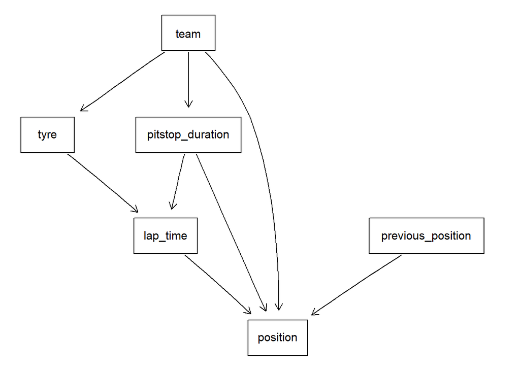

```r
library(bnlearn)
library(Rgraphviz)

# Choosing relevant variables
BAH2 <- BAH %>%  dplyr::select(c(lap_time, previous_position,
                                  tyre, team, position,
                                pitstop_duration))

dag_d = empty.graph(nodes = c("lap_time", "tyre", "team", "position", "pitstop_duration", "previous_position"))
# Known relationships
arc.set = matrix(c("team", "position",
                   "team", "tyre",
                   "lap_time", "position",
                   "tyre", "lap_time",
                  "pitstop_duration", "lap_time",
                   "pitstop_duration", "position",
                  "team", "pitstop_duration",
                  "previous_position", "position"),
                 byrow = TRUE, ncol=2, dimnames =list(NULL,c("from","to")))
arcs(dag_d) = arc.set
graphviz.plot(dag_d)
```

```r
arc.strength(dag_d, data = BAH2, criterion = "x2")
```

```
##                from               to      strength
## 1              team         position  1.000000e+00
## 2              team             tyre  1.143651e-50
## 3          lap_time         position  1.000000e+00
## 4              tyre         lap_time  3.734665e-01
## 5  pitstop_duration         lap_time 1.770481e-183
## 6  pitstop_duration         position  1.000000e+00
## 7              team pitstop_duration  5.963552e-05
## 8 previous_position         position  1.000000e+00
```

```r
bn.bayes_d = bn.fit(dag_d,data=BAH2, method = "bayes", iss = 10)

bn.bayes_d$pitstop_duration
```

```
##
##   Parameters of node pitstop_duration (ordinal distribution)
##
## Conditional probability table:
##
##                 team
## pitstop_duration  Alfa Romeo  AlphaTauri      Alpine Aston Martin     Ferrari
##      no_pitstop  0.948830409 0.948830409 0.930976431  0.957971014 0.950171821
##      [24.2,24.7] 0.001461988 0.010233918 0.001683502  0.010144928 0.042955326
##      (24.7,25.1] 0.001461988 0.010233918 0.031986532  0.010144928 0.001718213
##      (25.1,25.5] 0.019005848 0.019005848 0.001683502  0.010144928 0.001718213
##      (25.5,27.7] 0.019005848 0.010233918 0.011784512  0.010144928 0.001718213
##      (27.7,44.5] 0.010233918 0.001461988 0.021885522  0.001449275 0.001718213
##                 team
## pitstop_duration Haas F1 Team     McLaren    Mercedes Red Bull Racing
##      no_pitstop   0.939528024 0.900966184 0.957971014     0.957971014
##      [24.2,24.7]  0.001474926 0.002415459 0.010144928     0.018840580
##      (24.7,25.1]  0.001474926 0.002415459 0.018840580     0.010144928
##      (25.1,25.5]  0.028023599 0.002415459 0.001449275     0.010144928
##      (25.5,27.7]  0.019174041 0.002415459 0.010144928     0.001449275
##      (27.7,44.5]  0.010324484 0.089371981 0.001449275     0.001449275
##                 team
## pitstop_duration    Williams
##      no_pitstop  0.940058480
##      [24.2,24.7] 0.010233918
##      (24.7,25.1] 0.019005848
##      (25.1,25.5] 0.010233918
##      (25.5,27.7] 0.019005848
##      (27.7,44.5] 0.001461988
```

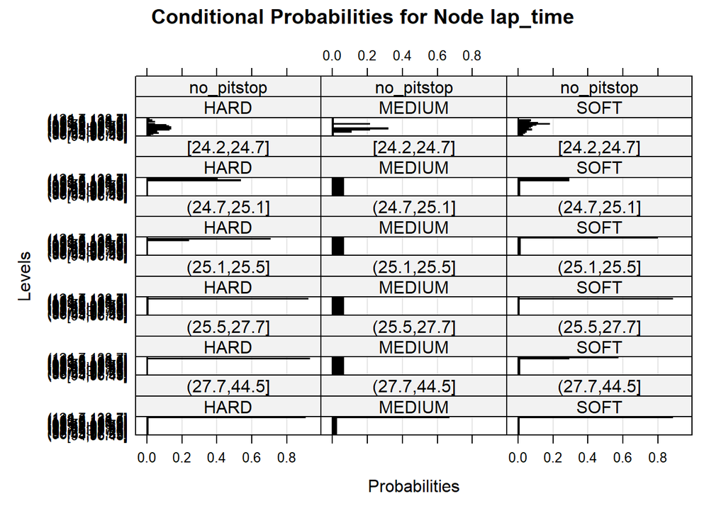

```r
bn.fit.barchart(bn.bayes_d$lap_time)
```

```r
bn.fit.barchart(bn.bayes_d$tyre)
```

[output not shown]

```r
bn.bayes_d$lap_time
```

```
##
##   Parameters of node lap_time (ordinal distribution)
##
## Conditional probability table:
##
## , , pitstop_duration = no_pitstop
##
##                tyre
## lap_time                HARD       MEDIUM         SOFT
##   [94,96.43]    1.806250e-02 3.633721e-03 2.725528e-02
##   (96.43,96.89] 3.606250e-02 3.633721e-03 2.499056e-02
##   (96.89,97.22] 6.486250e-02 3.633721e-03 3.857889e-02
##   (97.22,97.43] 5.586250e-02 1.082849e-01 4.763777e-02
##   (97.43,97.6]  5.766250e-02 1.082849e-01 4.310833e-02
##   (97.6,97.87]  1.260625e-01 2.129360e-01 7.707914e-02
##   (97.87,98.18] 1.368625e-01 3.175872e-01 5.896137e-02
##   (98.18,98.61] 1.350625e-01 3.633721e-03 7.028498e-02
##   (98.61,99.12] 1.242625e-01 3.633721e-03 8.160858e-02
##   (99.12,99.73] 1.080625e-01 3.633721e-03 1.019911e-01
##   (99.73,100.8] 4.506250e-02 2.129360e-01 1.789916e-01
##   (100.8,101.2] 5.462500e-03 3.633721e-03 1.110499e-01
##   (101.2,102.6] 4.326250e-02 3.633721e-03 6.575554e-02
##   (102.6,118.8] 2.706250e-02 3.633721e-03 7.028498e-02
##   (118.8,124.7] 3.662500e-03 3.633721e-03 2.343357e-03
##   (124.7,138.7] 1.266250e-02 3.633721e-03 7.863613e-05
##
## , , pitstop_duration = [24.2,24.7]
##
##                tyre
## lap_time                HARD       MEDIUM         SOFT
##   [94,96.43]    4.595588e-03 6.250000e-02 9.765625e-03
##   (96.43,96.89] 4.595588e-03 6.250000e-02 9.765625e-03
##   (96.89,97.22] 4.595588e-03 6.250000e-02 9.765625e-03
##   (97.22,97.43] 4.595588e-03 6.250000e-02 9.765625e-03
##   (97.43,97.6]  4.595588e-03 6.250000e-02 9.765625e-03
##   (97.6,97.87]  4.595588e-03 6.250000e-02 9.765625e-03
##   (97.87,98.18] 4.595588e-03 6.250000e-02 9.765625e-03
##   (98.18,98.61] 4.595588e-03 6.250000e-02 9.765625e-03
##   (98.61,99.12] 4.595588e-03 6.250000e-02 9.765625e-03
##   (99.12,99.73] 4.595588e-03 6.250000e-02 9.765625e-03
```

[output cut: 75 more lines]

```
##   (96.43,96.89] 6.250000e-03 2.232143e-02 7.621951e-03
##   (96.89,97.22] 6.250000e-03 2.232143e-02 7.621951e-03
##   (97.22,97.43] 6.250000e-03 2.232143e-02 7.621951e-03
##   (97.43,97.6]  6.250000e-03 2.232143e-02 7.621951e-03
##   (97.6,97.87]  6.250000e-03 2.232143e-02 7.621951e-03
##   (97.87,98.18] 6.250000e-03 2.232143e-02 7.621951e-03
##   (98.18,98.61] 6.250000e-03 2.232143e-02 7.621951e-03
##   (98.61,99.12] 6.250000e-03 2.232143e-02 7.621951e-03
##   (99.12,99.73] 6.250000e-03 2.232143e-02 7.621951e-03
##   (99.73,100.8] 6.250000e-03 2.232143e-02 7.621951e-03
##   (100.8,101.2] 6.250000e-03 2.232143e-02 7.621951e-03
##   (101.2,102.6] 6.250000e-03 2.232143e-02 7.621951e-03
##   (102.6,118.8] 6.250000e-03 2.232143e-02 7.621951e-03
##   (118.8,124.7] 6.250000e-03 2.232143e-02 7.621951e-03
##   (124.7,138.7] 9.062500e-01 6.651786e-01 8.856707e-01
```

```r
bn.bayes_d$tyre
```

```
##
##   Parameters of node tyre (multinomial distribution)
##
## Conditional probability table:
##
##         team
## tyre      Alfa Romeo  AlphaTauri      Alpine Aston Martin     Ferrari
##   HARD   0.581871345 0.660818713 0.609427609  0.742028986 0.725085911
##   MEDIUM 0.002923977 0.002923977 0.003367003  0.002898551 0.003436426
##   SOFT   0.415204678 0.336257310 0.387205387  0.255072464 0.271477663
##         team
## tyre     Haas F1 Team     McLaren    Mercedes Red Bull Racing    Williams
##   HARD    0.516224189 0.251207729 0.776811594     0.385507246 0.213450292
##   MEDIUM  0.002949853 0.149758454 0.002898551     0.002898551 0.002923977
##   SOFT    0.480825959 0.599033816 0.220289855     0.611594203 0.783625731
```

## DAG unknown: constraint-based method (incremental association Markov blanket)

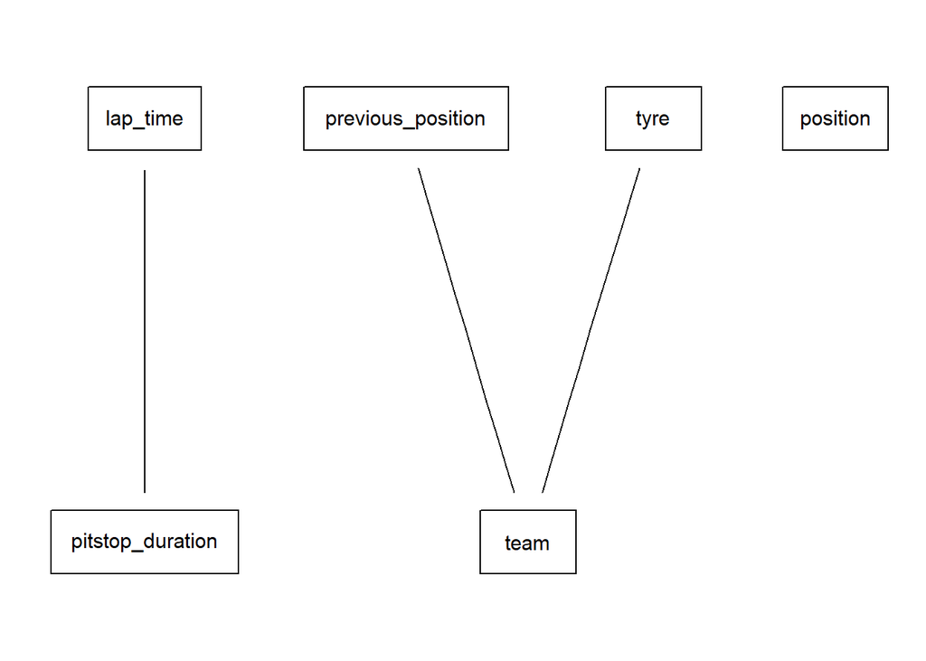

```r
BAH.iamb_naive_d =iamb(BAH2, test ='mi')
graphviz.plot(BAH.iamb_naive_d)
```

Make a blacklist representing the natural temporal ordering of variables

```r
# Blacklist variables so that chronological order is kept
bl = matrix(c(
              "lap_time", "pitstop_duration",
              "lap_time", "tyre"
             ),
            ncol = 2, byrow = TRUE)

# Nothing from position
for (name in names(BAH2)){
  bl2 = matrix(c("position", name), ncol=2,
            dimnames =list(NULL,c("from","to")))
  bl = rbind(bl, bl2)
}


# Nothing to team
for (name in names(BAH2)){
  bl3 = matrix(c(name, "team"), ncol=2,
            dimnames =list(NULL,c("from","to")))
  bl = rbind(bl, bl3)
}

bl
```

```
##       from                to
##  [1,] "lap_time"          "pitstop_duration"
##  [2,] "lap_time"          "tyre"
##  [3,] "position"          "lap_time"
##  [4,] "position"          "previous_position"
##  [5,] "position"          "tyre"
##  [6,] "position"          "team"
##  [7,] "position"          "position"
##  [8,] "position"          "pitstop_duration"
##  [9,] "lap_time"          "team"
## [10,] "previous_position" "team"
## [11,] "tyre"              "team"
## [12,] "team"              "team"
## [13,] "position"          "team"
## [14,] "pitstop_duration"  "team"
```

```r
wl = matrix(c(
              "previous_position", "position"
             ),
            ncol = 2, byrow = TRUE)
```

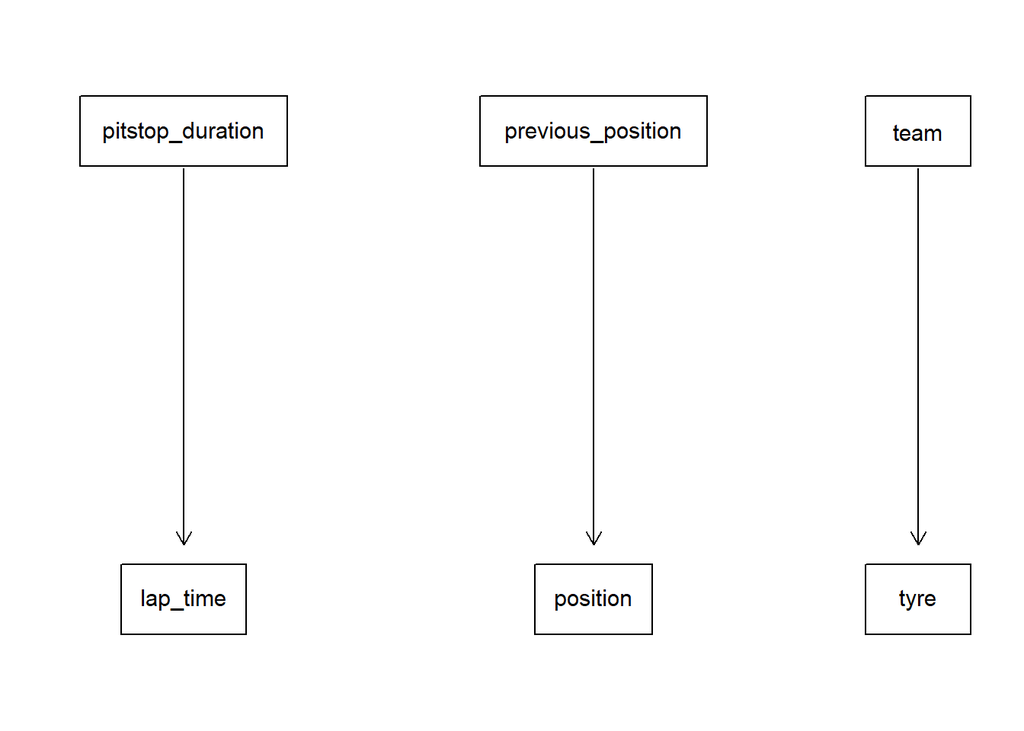

```r
BAH.iamb_d =iamb(BAH2, blacklist = bl, whitelist = wl, test ='mi')
graphviz.plot(BAH.iamb_d)
```

### Perform independence tests

```r
# Does pitstop influence lap time?
ci.test("lap_time","pitstop_duration", test = "mc-jt", data = BAH2)
```

```
##
##  Jonckheere-Terpstra (MC)
##
## data:  lap_time ~ pitstop_duration
## mc-jt = 11.857, Monte Carlo samples = 5000, p-value < 2.2e-16
## alternative hypothesis: true value is not equal to 0
```

```r
# Does team influence position?
ci.test("position", "team", test = "mc-mi", data = BAH2)
```

```
##
##  Mutual Information (disc., MC)
##
## data:  position ~ team
## mc-mi = 2666.5, Monte Carlo samples = 5000, p-value < 2.2e-16
## alternative hypothesis: true value is greater than 0
```

```r
# Does team influence tyre?
ci.test("tyre", "team", test = "mc-mi", data = BAH2)
```

```
##
##  Mutual Information (disc., MC)
##
## data:  tyre ~ team
## mc-mi = 204.29, Monte Carlo samples = 5000, p-value < 2.2e-16
## alternative hypothesis: true value is greater than 0
```

```r
# Does team influence pitstop_duration?
ci.test("pitstop_duration", "team", test = "mc-mi", data = BAH2)
```

```
##
##  Mutual Information (disc., MC)
##
## data:  pitstop_duration ~ team
## mc-mi = 73.072, Monte Carlo samples = 5000, p-value = 0.0088
## alternative hypothesis: true value is greater than 0
```

```r
# Does team influence lap_time?
ci.test("lap_time", "team", "pitstop_duration", test = "mc-mi", data = BAH2)
```

```
##
##  Mutual Information (disc., MC)
##
## data:  lap_time ~ team | pitstop_duration
## mc-mi = 384.91, Monte Carlo samples = 5000, p-value < 2.2e-16
## alternative hypothesis: true value is greater than 0
```

```r
# Does lap_time influence position?
ci.test("position", "lap_time", "team", test = "mc-mi", data = BAH2)
```

```
##
##  Mutual Information (disc., MC)
##
## data:  position ~ lap_time | team
## mc-mi = 1331.1, Monte Carlo samples = 5000, p-value < 2.2e-16
## alternative hypothesis: true value is greater than 0
```

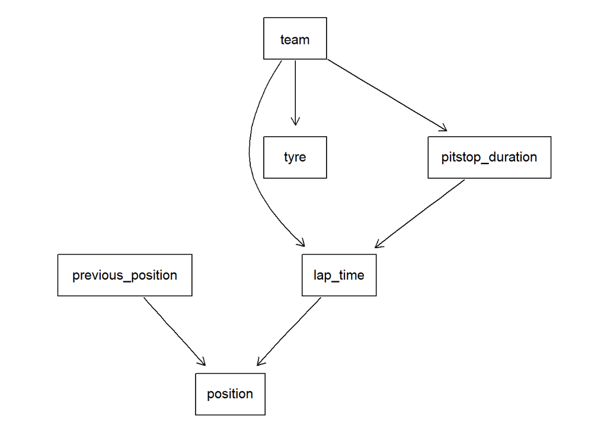

```r
# Add the arcs from conditional independence tests with resulting p-value < 0.05
tested_BAH.iamb_d = set.arc(BAH.iamb_d, from = "lap_time", to = "position")
tested_BAH.iamb_d = set.arc(tested_BAH.iamb_d, from = "team", to = "lap_time")
tested_BAH.iamb_d = set.arc(tested_BAH.iamb_d, from = "team", to = "pitstop_duration")


graphviz.plot(tested_BAH.iamb_d)
```

```r
# Does pitstop influence position?
ci.test("position", "pitstop_duration", c("lap_time", "previous_position"), test = "mc-jt", data = BAH2)
```

```
##
##  Jonckheere-Terpstra (MC)
##
## data:  position ~ pitstop_duration | lap_time + previous_position
## mc-jt = 2.2295, Monte Carlo samples = 5000, p-value = 0.0406
## alternative hypothesis: true value is not equal to 0
```

```r
# Does tyre influence lap time?
ci.test("lap_time","tyre", c("pitstop_duration", "team"), test = "mc-mi", data = BAH2)
```

```
##
##  Mutual Information (disc., MC)
##
## data:  lap_time ~ tyre | pitstop_duration + team
## mc-mi = 751.7, Monte Carlo samples = 5000, p-value < 2.2e-16
## alternative hypothesis: true value is greater than 0
```

```r
# Does team influence previous_position?
ci.test("previous_position","team", test = "mc-mi", data = BAH2)
```

```
##
##  Mutual Information (disc., MC)
##
## data:  previous_position ~ team
## mc-mi = 2639.6, Monte Carlo samples = 5000, p-value < 2.2e-16
## alternative hypothesis: true value is greater than 0
```

```r
# Does team influence position?
ci.test("position","team", "previous_position", test = "mc-mi", data = BAH2)
```

```
##
##  Mutual Information (disc., MC)
##
## data:  position ~ team | previous_position
## mc-mi = 451.82, Monte Carlo samples = 5000, p-value < 2.2e-16
## alternative hypothesis: true value is greater than 0
```

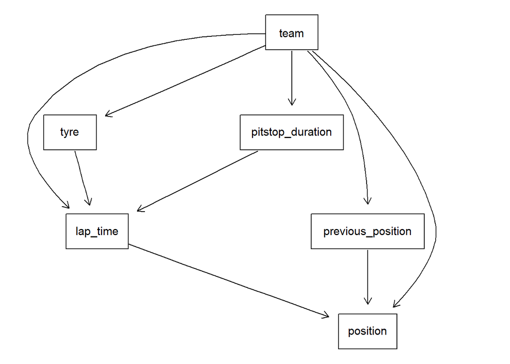

```r
tested_BAH.iamb_d = set.arc(tested_BAH.iamb_d, from = "tyre", to = "lap_time")
tested_BAH.iamb_d = set.arc(tested_BAH.iamb_d, from = "team", to = "position")
tested_BAH.iamb_d = set.arc(tested_BAH.iamb_d, from = "team", to = "previous_position")
graphviz.plot(tested_BAH.iamb_d)
```

## DAG uknown: score-based method (hill-climbing)

```r
# Use hill-climbing to determine the DAG
BAH.hc2 =hc(BAH2)
```

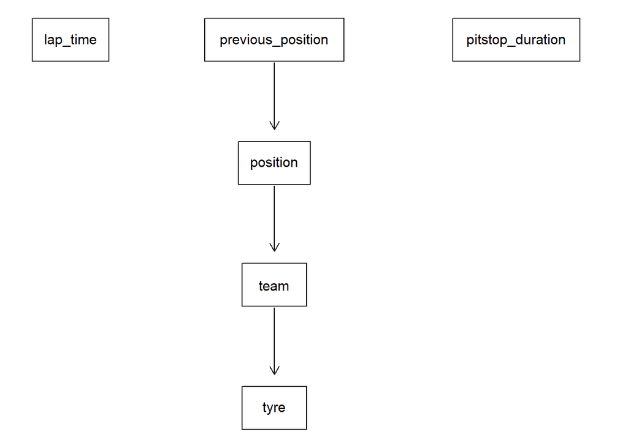

```r
graphviz.plot(BAH.hc2)
```

Learning DAG using hill climbing and whitelists, blacklists

```r
# Use hill-climbing to determine the DAG with blacklisting
BAH.hc_bl_d =hc(BAH2, blacklist = bl, whitelist = wl)
```

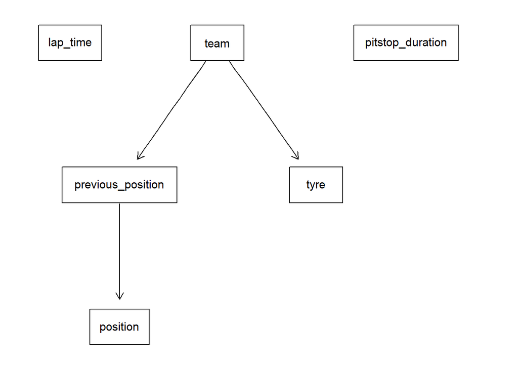

```r
graphviz.plot(BAH.hc_bl_d)
```

```r
arc.strength(BAH.hc_bl_d, data = BAH2, criterion = "x2")
```

```
##                from                to     strength
## 1 previous_position          position 0.000000e+00
## 2              team previous_position 0.000000e+00
## 3              team              tyre 1.143651e-50
```

### Scores

```r
# Known
score(dag_d, data = BAH2, type = "bic")
```

```
## [1] -1280147
```

```r
# IAMB
score(BAH.iamb_d, data = BAH2, type = "bic")
```

```
## [1] -11795.74
```

```r
score(tested_BAH.iamb_d, data = BAH2, type = "bic")
```

```
## [1] -229311.8
```

```r
# HC
score(BAH.hc2, data = BAH2, type = "bic")
```

```
## [1] -10977.72
```

```r
score(BAH.hc_bl_d, data = BAH2, type = "bic")
```

```
## [1] -10991.13
```

The known DAG seems to heavily underrepresent the dataset, with a very low BIC score. Notably, the IAMB with blacklisting fits the data better before the addition of arcs from conditional independence tests. Hill climbing results suggest that the addition of blacklists has not affected the score by much, with the penalty of adding more arcs.